# How it works

What’s inside, and what it costs. Four slides.

## What an LLM is

[figure not shown]

Training makes the model. Thinking happens on **your** question: the longer it thinks, the better the answer, and the more of your plan it uses.

## Prompt engineering (RIP)

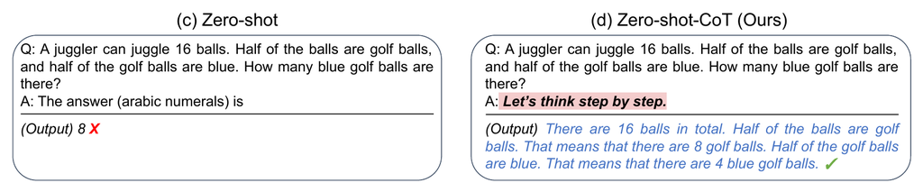

Kojima et al. (2022), *Large Language Models are Zero-Shot Reasoners*

- 2022 trick: add *“let’s think step by step”*, and maths goes from 18% to 79%.
- Now it’s built in: that’s the **thinking** stage.
- Magic words and templates? Mostly noise now.

## What an agent is

- An LLM **with tools**: it reads and writes files, runs programs, searches the web.
- **On your computer**, in the folder you start it in.
- It asks before it does anything big. **You say go.**
- A chat window only sees what you paste into it. **The agent works on the files themselves.**

Claude Code and Codex are agents.

## Usage limits

Every answer costs computing power. The strong models and long thinking cost the most.

- **Claude Pro** runs out sooner within a **five-hour window**. **ChatGPT Plus** runs out sooner over a **week**. Higher plans give many times more.
- **What eats it:** long sessions, big files, the strongest model, long thinking.
- **See where you stand:** `/usage` in Claude Code, `/status` in Codex.
- **Hit the limit?** Wait for the reset, switch to a Fast model with `/model`, or pair up. Hitting it every day? A higher plan is the fix.